# Machine Learning Engineer Nanodegree

## Project: Creating Customer Segments

Welcome to the third project of the Machine Learning Engineer Nanodegree! In this notebook, some template code has already been provided for you, and it will be your job to implement the additional functionality necessary to successfully complete this project. Sections that begin with **'Implementation'** in the header indicate that the following block of code will require additional functionality which you must provide. Instructions will be provided for each section and the specifics of the implementation are marked in the code block with a `'TODO'` statement. Please be sure to read the instructions carefully!

In addition to implementing code, there will be questions that you must answer which relate to the project and your implementation. Each section where you will answer a question is preceded by a **'Question X'** header. Carefully read each question and provide thorough answers in the following text boxes that begin with **'Answer:'**. Your project submission will be evaluated based on your answers to each of the questions and the implementation you provide.

> **Note:** Code and Markdown cells can be executed using the **Shift + Enter** keyboard shortcut. In addition, Markdown cells can be edited by typically double-clicking the cell to enter edit mode.

## Getting Started

In this project, you will analyze a dataset containing data on various customers' annual spending amounts (reported in *monetary units*) of diverse product categories for internal structure. One goal of this project is to best describe the variation in the different types of customers that a wholesale distributor interacts with. Doing so would equip the distributor with insight into how to best structure their delivery service to meet the needs of each customer.

The dataset for this project can be found on the [UCI Machine Learning Repository](https://archive.ics.uci.edu/ml/datasets/Wholesale+customers). For the purposes of this project, the features `'Channel'` and `'Region'` will be excluded in the analysis — with focus instead on the six product categories recorded for customers.

Run the code block below to load the wholesale customers dataset, along with a few of the necessary Python libraries required for this project. You will know the dataset loaded successfully if the size of the dataset is reported.

```python
# Import libraries necessary for this project
import numpy as np
import pandas as pd
from IPython.display import display # Allows the use of display() for DataFrames

# Import supplementary visualizations code visuals.py
import visuals as vs

# Pretty display for notebooks
%matplotlib inline

# Load the wholesale customers dataset
try:
    data = pd.read_csv("customers.csv")
    data.drop(['Region', 'Channel'], axis = 1, inplace = True)
    print "Wholesale customers dataset has {} samples with {} features each.".format(*data.shape)
except:
    print "Dataset could not be loaded. Is the dataset missing?"
```

```
Wholesale customers dataset has 440 samples with 6 features each.
```

## Data Exploration

In this section, you will begin exploring the data through visualizations and code to understand how each feature is related to the others. You will observe a statistical description of the dataset, consider the relevance of each feature, and select a few sample data points from the dataset which you will track through the course of this project.

Run the code block below to observe a statistical description of the dataset. Note that the dataset is composed of six important product categories: **'Fresh'**, **'Milk'**, **'Grocery'**, **'Frozen'**, **'Detergents_Paper'**, and **'Delicatessen'**. Consider what each category represents in terms of products you could purchase.

```python
# Display a description of the dataset
display(data.describe())
```

|  | Fresh | Milk | Grocery | Frozen | Detergents_Paper | Delicatessen |
| --- | --- | --- | --- | --- | --- | --- |
| count | 440.000000 | 440.000000 | 440.000000 | 440.000000 | 440.000000 | 440.000000 |
| mean | 12000.297727 | 5796.265909 | 7951.277273 | 3071.931818 | 2881.493182 | 1524.870455 |
| std | 12647.328865 | 7380.377175 | 9503.162829 | 4854.673333 | 4767.854448 | 2820.105937 |
| min | 3.000000 | 55.000000 | 3.000000 | 25.000000 | 3.000000 | 3.000000 |
| 25% | 3127.750000 | 1533.000000 | 2153.000000 | 742.250000 | 256.750000 | 408.250000 |
| 50% | 8504.000000 | 3627.000000 | 4755.500000 | 1526.000000 | 816.500000 | 965.500000 |
| 75% | 16933.750000 | 7190.250000 | 10655.750000 | 3554.250000 | 3922.000000 | 1820.250000 |
| max | 112151.000000 | 73498.000000 | 92780.000000 | 60869.000000 | 40827.000000 | 47943.000000 |

### Implementation: Selecting Samples

To get a better understanding of the customers and how their data will transform through the analysis, it would be best to select a few sample data points and explore them in more detail. In the code block below, add **three** indices of your choice to the `indices` list which will represent the customers to track. It is suggested to try different sets of samples until you obtain customers that vary significantly from one another.

```python
def find_mean(colmns, lmt):
    meanlist = data[colmns].mean()
    display(meanlist)
    def inRange(sr):
        ret = True
        for i, r in sr.iteritems():
            amean = meanlist[i]
            inr = (amean*(1-lmt) < r) & (r < amean*(1+lmt))
            ret = ret & inr
    #         print "check {} in {} is {}".format(r,i, inr)
        return ret
    return data[data[colmns].apply(lambda x: inRange(x), axis=1)]

display(find_mean(['Grocery','Detergents_Paper','Frozen','Milk'], 0.35))
display(find_mean(['Delicatessen','Frozen','Fresh'], 0.21))
```

```
Grocery             7951.277273
Detergents_Paper    2881.493182
Frozen              3071.931818
Milk                5796.265909
dtype: float64
```

|  | Fresh | Milk | Grocery | Frozen | Detergents_Paper | Delicatessen |
| --- | --- | --- | --- | --- | --- | --- |
| 18 | 18601 | 6327 | 10099 | 2205 | 2767 | 3181 |
| 164 | 5224 | 7603 | 8584 | 2540 | 3674 | 238 |

```
Delicatessen     1524.870455
Frozen           3071.931818
Fresh           12000.297727
dtype: float64
```

|  | Fresh | Milk | Grocery | Frozen | Detergents_Paper | Delicatessen |
| --- | --- | --- | --- | --- | --- | --- |
| 113 | 14438 | 2295 | 1733 | 3220 | 585 | 1561 |

```python
# TODO: Select three indices of your choice you wish to sample from the dataset
indices = [18, 164, 113]

# Create a DataFrame of the chosen samples
samples = pd.DataFrame(data.loc[indices], columns = data.keys())
print "Chosen samples of wholesale customers dataset:"
display(samples)
```

```
Chosen samples of wholesale customers dataset:
```

|  | Fresh | Milk | Grocery | Frozen | Detergents_Paper | Delicatessen |
| --- | --- | --- | --- | --- | --- | --- |
| 18 | 18601 | 6327 | 10099 | 2205 | 2767 | 3181 |
| 164 | 5224 | 7603 | 8584 | 2540 | 3674 | 238 |
| 113 | 14438 | 2295 | 1733 | 3220 | 585 | 1561 |

### Question 1

Consider the total purchase cost of each product category and the statistical description of the dataset above for your sample customers.

- What kind of establishment (customer) could each of the three samples you've chosen represent?

Knowing this, how do your samples compare? Does that help in driving your insight into what kind of establishments they might be?

**First visual comparsion of the samples with data mean and median.**

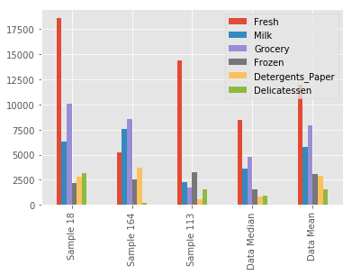

```python
import matplotlib.pyplot as plt
samples_cpy = samples.copy()
samples_cpy.at[samples.shape[0]] = data.median()
samples_cpy.at[samples.shape[0]+1] = data.mean()

plt.style.use('ggplot')

samples_cpy.plot(kind='bar')
labels = ["Sample {}".format(i) for i in samples.index]
labels.append("Data Median")
labels.append("Data Mean")
plt.xticks(range(samples_cpy.shape[0]), labels);
```

**Each features has different means and scales, it is difficult to compare them from the raw data. We need to scale all the features with a standard before we can compare it. Below shows the scaling of the data using the standardizated technique. All the features have been converted into zero mean and divided by the standard deviation.**

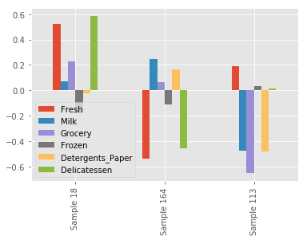

```python
samples_for_plot = samples.copy()
samples_for_plot = (samples_for_plot - data.mean())/data.std()

labels = ["Sample {}".format(i) for i in samples.index]
samples_for_plot.plot(kind='bar')
plt.xticks(range(3), labels);
```

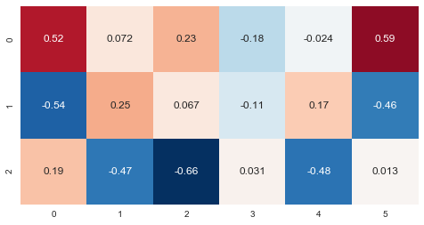

```python
## Standardization
import seaborn as sns
from sklearn.preprocessing import StandardScaler

ssc = StandardScaler()
ssc.fit(data)
sns.heatmap(ssc.transform(samples), annot=True, cbar=False, square=True);
```

**Answer:**

First establishment that I think would be resturant/cafe that need 'Delicatessen','Frozen','Fresh'. Therefore I scan the data set and try to find a client which is close to the mean of these three categories. The client **113** has 'Fresh', 'Frozen' and 'Delicatessen' quite close to the mean of the categories:

|  | Fresh | Milk | Grocery | Frozen | Detergents_paper | Delicatessen |
| --- | --- | --- | --- | --- | --- | --- |
| 113 | 14438 | 2295 | 1733 | 3220 | 585 | 1561 |

|  | Fresh | Milk | Grocery | Frozen | Detergents_paper | Delicatessen |
| --- | --- | --- | --- | --- | --- | --- |
| mean | 12000 | 5796 | 7951 | 3071 | 2881 | 1524 |

Second establishment that I come up is market/grocery store that I scan the data set to find clients that is close to mean of 'Detergents_Paper' and 'Grocery'. From there, I found client **18** and **164** is the closest to mean of both categories:

|  | Fresh | Milk | Grocery | Frozen | Detergents_paper | Delicatessen |
| --- | --- | --- | --- | --- | --- | --- |
| 18 | 18601 | 6327 | 10099 | 2205 | 2767 | 3181 |
| 164 | 5224 | 7603 | 8584 | 2540 | 3674 | 238 |

Even though both **18** and **164** are picked the same rules, **18** has higher than 75% and **164** is about 30%~40% in 'Fresh'. In 'Delicatessen', **18** is again higher than 75% and **164** has lower than 25%. These should be kept these two clients quite apart even in the same group.

### Implementation: Feature Relevance

One interesting thought to consider is if one (or more) of the six product categories is actually relevant for understanding customer purchasing. That is to say, is it possible to determine whether customers purchasing some amount of one category of products will necessarily purchase some proportional amount of another category of products? We can make this determination quite easily by training a supervised regression learner on a subset of the data with one feature removed, and then score how well that model can predict the removed feature.

In the code block below, you will need to implement the following:

- Assign `new_data` a copy of the data by removing a feature of your choice using the `DataFrame.drop` function.
- Use `sklearn.cross_validation.train_test_split` to split the dataset into training and testing sets.
  - Use the removed feature as your target label. Set a `test_size` of `0.25` and set a `random_state`.
- Import a decision tree regressor, set a `random_state`, and fit the learner to the training data.
- Report the prediction score of the testing set using the regressor's `score` function.

```python
from sklearn.cross_validation import train_test_split
from sklearn.tree  import DecisionTreeRegressor

collist = data.columns
numtest = 100

print "** Score based on average of {} calculations:".format(numtest)
for col in data.columns:
    new_data = data.drop(col, axis=1)

    scores=[]
    for i in range(0, numtest):
        # TODO: Split the data into training and testing sets(0.25) using the given feature as the target
        # Set a random state.
        X_train, X_test, y_train, y_test = train_test_split(new_data, data[col], test_size=0.25)

        # TODO: Create a decision tree regressor and fit it to the training set
        regressor = DecisionTreeRegressor()
        regressor.fit(X_train, y_train)

        # TODO: Report the score of the prediction using the testing set
        scores.append(regressor.score(X_test, y_test))

    print " {} score is {}".format(col, np.mean(scores))
```

```
** Score based on average of 100 calculations:
 Fresh score is -0.714509405362
 Milk score is 0.168467167927
 Grocery score is 0.670705700973
 Frozen score is -1.17284373584
 Detergents_Paper score is 0.680508674138
 Delicatessen score is -3.49377292122
```

### Question 2

- Which feature did you attempt to predict?
- What was the reported prediction score?
- Is this feature necessary for identifying customers' spending habits?

**Hint:** The coefficient of determination, `R^2`, is scored between 0 and 1, with 1 being a perfect fit. A negative `R^2` implies the model fails to fit the data. If you get a low score for a particular feature, that lends us to beleive that that feature point is hard to predict using the other features, thereby making it an important feature to consider when considering relevance.

**Answer:**

Instead of doing the scoring on one features, I poll out all six features separately and print out their scores. The features **Detergents_Paper**, **Grocery** and **Milk** are positive score. That means these features are highly relevance with with other features. **Milk** has a lower score may imply that it is not as relevance as **Detergents_Paper**, and **Grocery**. Therefore they are not important features to identify customers' spending habits. On the other hand, the **Fresh**, **Delicatessen** and **Frozen** have negative score indicate that they are very independent features that cannot be relevance with other features. Therefore they are the important features to use for clustering the customers' spending habits.

### Visualize Feature Distributions

To get a better understanding of the dataset, we can construct a scatter matrix of each of the six product features present in the data. If you found that the feature you attempted to predict above is relevant for identifying a specific customer, then the scatter matrix below may not show any correlation between that feature and the others. Conversely, if you believe that feature is not relevant for identifying a specific customer, the scatter matrix might show a correlation between that feature and another feature in the data. Run the code block below to produce a scatter matrix.

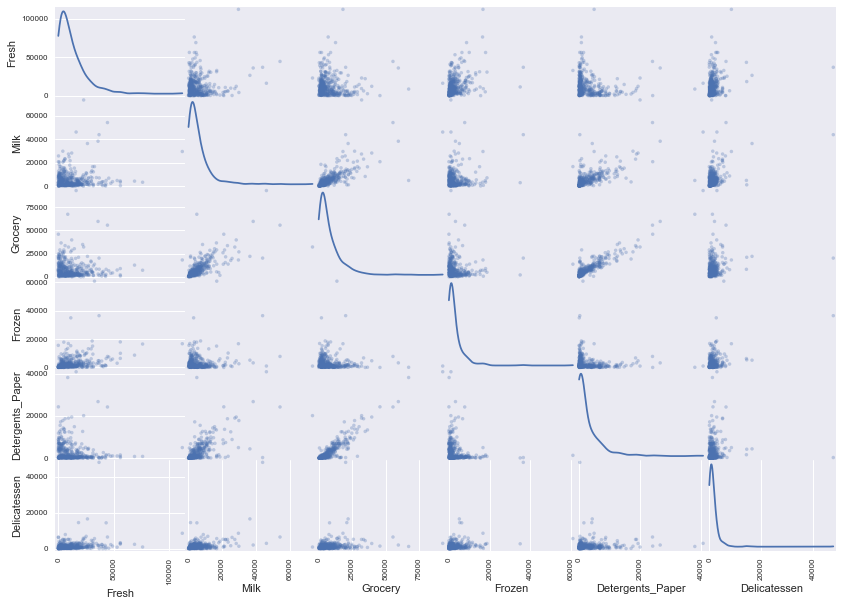

```python
# Produce a scatter matrix for each pair of features in the data
pd.scatter_matrix(data, alpha = 0.3, figsize = (14,10), diagonal = 'kde');
```

### Question 3

- Using the scatter matrix as a reference, discuss the distribution of the dataset, specifically talk about the normality, outliers, large number of data points near 0 among others. If you need to sepearate out some of the plots individually to further accentuate your point, you may do so as well.
- Are there any pairs of features which exhibit some degree of correlation?
- Does this confirm or deny your suspicions about the relevance of the feature you attempted to predict?
- How is the data for those features distributed?

**Hint:** Is the data normally distributed? Where do most of the data points lie? You can use [corr()](https://pandas.pydata.org/pandas-docs/stable/generated/pandas.DataFrame.corr.html) to get the feature correlations and then visualize them using a [heatmap](http://seaborn.pydata.org/generated/seaborn.heatmap.html)(the data that would be fed into the heatmap would be the correlation values, for eg: `data.corr()`) to gain further insight.

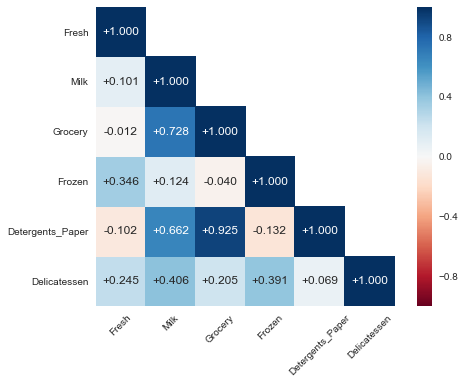

```python
##   Alternative display a heatmap of corr()
corr = data.corr()
mask = np.zeros_like(corr)
mask[np.triu_indices_from(mask, 1)] = True
with sns.axes_style("white"):
    ax = sns.heatmap(corr, mask=mask, square=True, annot=True,
                     cmap='RdBu', fmt='+.3f')
    plt.xticks(rotation=45, ha='center')
```

```python
# from seaborn import heatmap
# heatmap(data.corr());
```

**Answer:**

From the scatter matrix, we can see the clients spending is mostly below mean. That is a lot of dots in the lower left corner of chart of each of the feature pairs. However there are a few outliner that I like to call them high value clients that with high purchase of each of the features(categories). If we go back to the very beginning of the statistic of the all features(categories), the max of each categories spend almost 10 times more over 75% of other clients. That reminds me about a business rule of 20/80, ie, 20% of clients can bring 80% of income of your company income.

The chart showing the **Detergents_Paper** and **Grocery** pair has a data scattered along the diagonal line. That shows the pair has some correlation. The above heatmap of correction of feature pairs confirms this obsveration. Interesting, **Milk** is also correlated with **Detergents_Paper** and **Grocery** in a lesser degree.

The result here is matched with my observation in Question 2 has **Detergents_Paper**, **Grocery** and **Milk** are **Relevance Features** which are not important features to cluster customers'.

But then **Fresh**, **Frozen** and **Delicatessen** are showing less correlation in the heatmap and that is matching the observation in Question 2. Therefore here again to confirm that they are important features to identify customers' spending habits.

## Data Preprocessing

In this section, you will preprocess the data to create a better representation of customers by performing a scaling on the data and detecting (and optionally removing) outliers. Preprocessing data is often times a critical step in assuring that results you obtain from your analysis are significant and meaningful.

### Implementation: Feature Scaling

If data is not normally distributed, especially if the mean and median vary significantly (indicating a large skew), it is most [often appropriate](http://econbrowser.com/archives/2014/02/use-of-logarithms-in-economics) to apply a non-linear scaling — particularly for financial data. One way to achieve this scaling is by using a [Box-Cox test](http://scipy.github.io/devdocs/generated/scipy.stats.boxcox.html), which calculates the best power transformation of the data that reduces skewness. A simpler approach which can work in most cases would be applying the natural logarithm.

In the code block below, you will need to implement the following:

- Assign a copy of the data to `log_data` after applying logarithmic scaling. Use the `np.log` function for this.
- Assign a copy of the sample data to `log_samples` after applying logarithmic scaling. Again, use `np.log`.

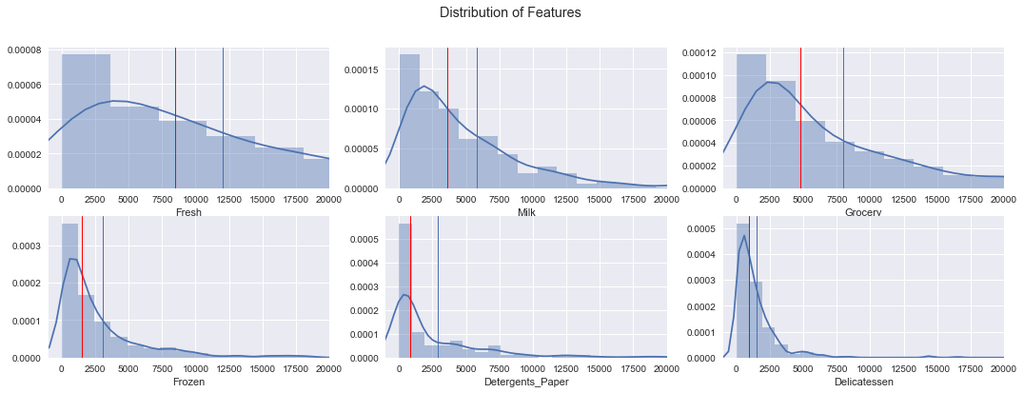

```python
fig, axes = plt.subplots(2, 3)
axes = axes.flatten()
fig.set_size_inches(18, 6)
fig.suptitle('Distribution of Features')

for i, col in enumerate(data.columns):
    feature = data[col]
    sns.distplot(feature, label=col, ax=axes[i]).set(xlim=(-1000, 20000),)
    axes[i].axvline(feature.mean(),linewidth=1)
    axes[i].axvline(feature.median(),linewidth=1, color='r')
```

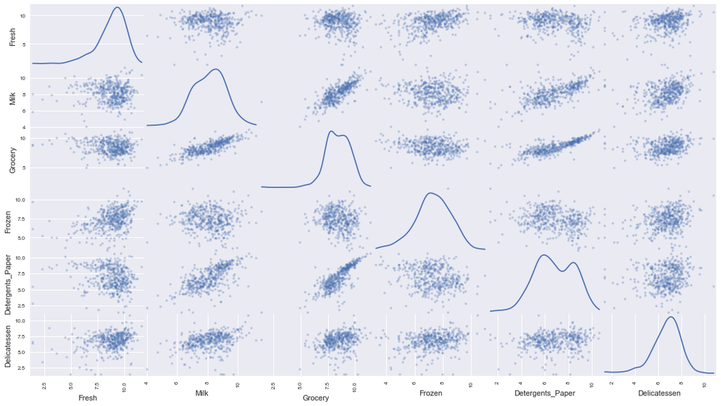

```python
# TODO: Scale the data using the natural logarithm
log_data = data.apply(lambda x: np.log(x + 1))

# TODO: Scale the sample data using the natural logarithm
log_samples = samples.apply(lambda x: np.log(x + 1))

# Produce a scatter matrix for each pair of newly-transformed features
pd.scatter_matrix(log_data, alpha = 0.3, figsize = (18,10), diagonal = 'kde');
```

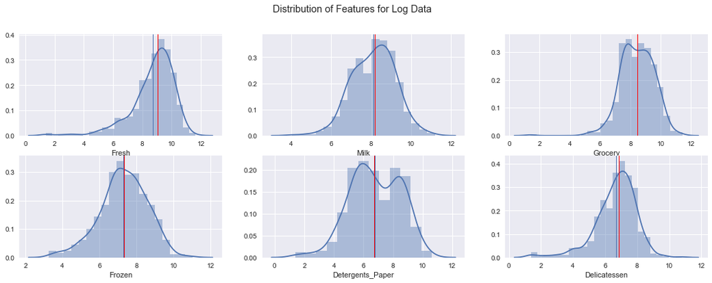

```python
fig, axes = plt.subplots(2, 3)
axes = axes.flatten()
fig.set_size_inches(18, 6)
fig.suptitle('Distribution of Features for Log Data')

for i, col in enumerate(log_data.columns):
    feature = log_data[col]
    sns.distplot(feature, label=col, ax=axes[i])
    axes[i].axvline(feature.mean(),linewidth=1)
    axes[i].axvline(feature.median(),linewidth=1, color='r')
```

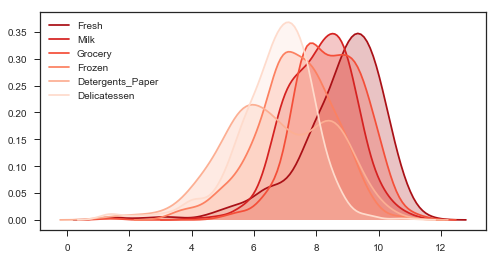

```python
import matplotlib.pyplot as plt
import seaborn as sns
# set plot style & color scheme
sns.set_style('ticks')
with sns.color_palette("Reds_r"):
    # plot densities of log data
    plt.figure(figsize=(8,4))
    for col in data.columns:
        sns.kdeplot(log_data[col], shade=True)
    plt.legend(loc='best')
```

**Applying Standard Scaler to the data make all features has mean of zero and variance of 1.**

```python
from sklearn.preprocessing import StandardScaler

scaler = StandardScaler()
scaler.fit(log_data)

log_data = pd.DataFrame(np.round(scaler.transform(log_data),4), columns = log_data.columns, index=log_data.index)
log_samples = pd.DataFrame(np.round(scaler.transform(log_samples),4), columns = log_samples.columns, index=log_samples.index)
```

```python
print "Statistical information of the data after the Normalization"
display(log_data.describe())
```

```
Statistical information of the data after the Normalization
```

|  | Fresh | Milk | Grocery | Frozen | Detergents_Paper | Delicatessen |
| --- | --- | --- | --- | --- | --- | --- |
| count | 440.000000 | 440.000000 | 440.000000 | 4.400000e+02 | 4.400000e+02 | 4.400000e+02 |
| mean | 0.000002 | -0.000002 | 0.000002 | 4.545455e-07 | 4.545455e-07 | 2.272727e-07 |
| std | 1.001138 | 1.001140 | 1.001137 | 1.001139e+00 | 1.001138e+00 | 1.001143e+00 |
| min | -5.001200 | -3.794900 | -6.355200 | -3.159100e+00 | -3.165600e+00 | -4.088900e+00 |
| 25% | -0.465900 | -0.728200 | -0.690950 | -5.405500e-01 | -7.260750e-01 | -5.081250e-01 |
| 50% | 0.214850 | 0.069300 | 0.022600 | 2.180000e-02 | -5.010000e-02 | 1.567000e-01 |
| 75% | 0.683725 | 0.703200 | 0.749125 | 6.818500e-01 | 8.683500e-01 | 6.469250e-01 |
| max | 1.970700 | 2.856600 | 2.698300 | 2.900100e+00 | 2.240200e+00 | 3.177400e+00 |

### Observation

After applying a natural logarithm scaling to the data, the distribution of each feature should appear much more normal. For any pairs of features you may have identified earlier as being correlated, observe here whether that correlation is still present (and whether it is now stronger or weaker than before).

Run the code below to see how the sample data has changed after having the natural logarithm applied to it.

```python
# Display the log-transformed sample data
display(log_samples)
```

|  | Fresh | Milk | Grocery | Frozen | Detergents_Paper | Delicatessen |
| --- | --- | --- | --- | --- | --- | --- |
| 18 | 0.7476 | 0.5847 | 0.7008 | 0.3091 | 0.6642 | 1.0787 |
| 164 | -0.1168 | 0.7549 | 0.5544 | 0.4195 | 0.8301 | -0.9243 |
| 113 | 0.5752 | -0.3545 | -0.8863 | 0.6047 | -0.2451 | 0.5281 |

### Implementation: Outlier Detection

Detecting outliers in the data is extremely important in the data preprocessing step of any analysis. The presence of outliers can often skew results which take into consideration these data points. There are many "rules of thumb" for what constitutes an outlier in a dataset. Here, we will use [Tukey's Method for identfying outliers](http://datapigtechnologies.com/blog/index.php/highlighting-outliers-in-your-data-with-the-tukey-method/): An *outlier step* is calculated as 1.5 times the interquartile range (IQR). A data point with a feature that is beyond an outlier step outside of the IQR for that feature is considered abnormal.

In the code block below, you will need to implement the following:

- Assign the value of the 25th percentile for the given feature to `Q1`. Use `np.percentile` for this.
- Assign the value of the 75th percentile for the given feature to `Q3`. Again, use `np.percentile`.
- Assign the calculation of an outlier step for the given feature to `step`.
- Optionally remove data points from the dataset by adding indices to the `outliers` list.

**NOTE:** If you choose to remove any outliers, ensure that the sample data does not contain any of these points!  
Once you have performed this implementation, the dataset will be stored in the variable `good_data`.

```python
# For each feature find the data points with extreme high or low values
from collections import Counter

cnt = Counter()
dupcnt = Counter()
stepRate = 1.5

for feature in log_data.keys():

    # TODO: Calculate Q1 (25th percentile of the data) for the given feature
    Q1 = np.percentile(log_data[feature], 25)

    # TODO: Calculate Q3 (75th percentile of the data) for the given feature
    Q3 = np.percentile(log_data[feature], 75)

    # TODO: Use the interquartile range to calculate an outlier step (1.5 times the interquartile range)
    step = (Q3-Q1) * stepRate

    # Display the outliers
    print "Data points considered outliers for the feature '{}' outside of {} - {}:".format(feature, Q1-step, Q3+step)
    cnt.update(log_data[~((log_data[feature] >= Q1 - step) & (log_data[feature] <= Q3 + step))].index)
    display(log_data[~((log_data[feature] >= Q1 - step) & (log_data[feature] <= Q3 + step))].index)
    display(log_data[~((log_data[feature] >= Q1 - step) & (log_data[feature] <= Q3 + step))])

for k,v in cnt.items():
    if v > 1:
        dupcnt.update({k:v})

print " Step Rate to find IQR : {}".format(stepRate)
print " Outliers combined from all features : {}".format(cnt)
print " Outliers in more than one features : {}".format(dupcnt)

# OPTIONAL: Select the indices for data points you wish to remove
if stepRate > 1.5:
    outliers = list(cnt)
else:
    outliers  = list(dupcnt)

print " Final Outliers : {}".format(outliers)

# Remove the outliers, if any were specified
good_data = log_data.drop(log_data.index[outliers]).reset_index(drop = True)
```

```
Data points considered outliers for the feature 'Fresh' outside of -2.1903375 - 2.4081625:
```

```
Int64Index([65, 66, 81, 95, 96, 128, 171, 193, 218, 304, 305, 338, 353, 355,
            357, 412],
           dtype='int64')
```

|  | Fresh | Milk | Grocery | Frozen | Detergents_Paper | Delicatessen |
| --- | --- | --- | --- | --- | --- | --- |
| 65 | -2.9126 | 1.6942 | 2.0630 | -2.8836 | 1.9347 | 0.4566 |
| 66 | -4.3774 | -0.7276 | 0.4228 | -1.6656 | 0.7964 | -2.5833 |
| 81 | -2.2732 | 0.9651 | 1.0205 | -1.2919 | 1.2723 | -1.2494 |
| 95 | -5.0012 | -0.1315 | 0.2690 | -0.9482 | -0.8082 | -0.0819 |
| 96 | -3.7815 | -0.2333 | 0.5042 | -1.8115 | 0.8612 | -0.9954 |
| 128 | -2.5760 | 0.8952 | -0.1740 | -1.8277 | 0.1037 | -4.0889 |
| 171 | -2.3347 | 1.8890 | 1.3079 | -0.6428 | 1.3398 | 1.6011 |
| 193 | -2.4060 | 0.0323 | 1.3293 | -0.3407 | 1.0788 | -0.1302 |
| 218 | -3.9405 | 0.7427 | 1.0693 | -0.1123 | 0.9863 | 1.6161 |
| 304 | -2.4815 | 0.7373 | 1.5090 | -0.6846 | 1.5125 | 0.8640 |
| 305 | -2.2027 | 1.2474 | 0.5821 | -0.4831 | 0.8664 | -1.0170 |
| 338 | -5.0012 | -2.1405 | 0.3734 | 1.8369 | -2.3537 | -0.2780 |
| 353 | -2.6973 | 0.5754 | 1.3688 | -1.4600 | 1.3337 | 0.2652 |
| 355 | -2.3694 | -1.4187 | -0.7519 | -1.4041 | -0.9203 | -1.4074 |
| 357 | -3.4686 | -0.8988 | 1.4131 | -1.8555 | 1.1860 | -1.5177 |
| 412 | -2.8237 | 0.0637 | 0.8857 | -2.1149 | 0.7056 | -1.9559 |

```
Data points considered outliers for the feature 'Milk' outside of -2.8753 - 2.8503:
```

```
Int64Index([86, 98, 154, 356], dtype='int64')
```

|  | Fresh | Milk | Grocery | Frozen | Detergents_Paper | Delicatessen |
| --- | --- | --- | --- | --- | --- | --- |
| 86 | 0.8899 | 2.8566 | 1.7427 | -0.3182 | 1.8244 | 0.1050 |
| 98 | -1.7089 | -3.1445 | -1.6070 | -0.3945 | -1.6097 | -1.3778 |
| 154 | -1.5646 | -3.7949 | -3.1659 | -2.3214 | -2.7597 | -3.4614 |
| 356 | 0.8828 | -2.9797 | -2.7499 | 0.5893 | -2.6290 | -0.2809 |

```
Data points considered outliers for the feature 'Grocery' outside of -2.8510625 - 2.9092375:
```

```
Int64Index([75, 154], dtype='int64')
```

|  | Fresh | Milk | Grocery | Frozen | Detergents_Paper | Delicatessen |
| --- | --- | --- | --- | --- | --- | --- |
| 75 | 0.8104 | -1.0048 | -6.3552 | 0.8498 | -3.1656 | 0.1643 |
| 154 | -1.5646 | -3.7949 | -3.1659 | -2.3214 | -2.7597 | -3.4614 |

```
Data points considered outliers for the feature 'Frozen' outside of -2.37415 - 2.51545:
```

```
Int64Index([38, 57, 65, 145, 175, 264, 325, 420, 429, 439], dtype='int64')
```

|  | Fresh | Milk | Grocery | Frozen | Detergents_Paper | Delicatessen |
| --- | --- | --- | --- | --- | --- | --- |
| 38 | -0.2047 | 1.4283 | 1.1543 | -2.9496 | 1.2039 | -0.4627 |
| 57 | -0.0921 | 1.0025 | 0.7348 | -2.8425 | 1.2536 | 0.3759 |
| 65 | -2.9126 | 1.6942 | 2.0630 | -2.8836 | 1.9347 | 0.4566 |
| 145 | 0.8631 | 0.8455 | 1.8149 | -2.7662 | 1.5513 | 1.3349 |
| 175 | -0.6625 | 0.7839 | 0.8466 | -2.6029 | 0.9079 | 0.5927 |
| 264 | -1.1938 | 0.9785 | 1.0834 | -2.4804 | 1.1154 | 0.3656 |
| 325 | 1.1320 | 1.4884 | 0.9706 | 2.9001 | 0.2093 | 1.5174 |
| 420 | -0.2250 | 0.4147 | 0.9438 | -3.1591 | 1.1922 | 0.4401 |
| 429 | 0.2230 | -0.6056 | -0.2331 | -2.6803 | -1.3757 | 0.8927 |
| 439 | -0.5444 | -0.6335 | -0.5528 | -2.4316 | -0.3644 | -2.0896 |

```
Data points considered outliers for the feature 'Detergents_Paper' outside of -3.1177125 - 3.2599875:
```

```
Int64Index([75, 161], dtype='int64')
```

|  | Fresh | Milk | Grocery | Frozen | Detergents_Paper | Delicatessen |
| --- | --- | --- | --- | --- | --- | --- |
| 75 | 0.8104 | -1.0048 | -6.3552 | 0.8498 | -3.1656 | 0.1643 |
| 161 | 0.4734 | -1.6937 | -2.5158 | -0.2393 | -3.1656 | 0.8050 |

```
Data points considered outliers for the feature 'Delicatessen' outside of -2.2407 - 2.3795:
```

```
Int64Index([66, 109, 128, 137, 142, 154, 183, 184, 187, 203, 233, 285, 289,
            343],
           dtype='int64')
```

|  | Fresh | Milk | Grocery | Frozen | Detergents_Paper | Delicatessen |
| --- | --- | --- | --- | --- | --- | --- |
| 66 | -4.3774 | -0.7276 | 0.4228 | -1.6656 | 0.7964 | -2.5833 |
| 109 | -1.0100 | 1.4854 | 1.6504 | -0.6169 | -0.0363 | -4.0889 |
| 128 | -2.5760 | 0.8952 | -0.1740 | -1.8277 | 0.1037 | -4.0889 |
| 137 | -0.4749 | 0.8112 | 0.5222 | -0.6309 | -0.1228 | -2.3677 |
| 142 | 1.2164 | 0.6982 | 0.5190 | 0.5482 | -2.1945 | -4.0889 |
| 154 | -1.5646 | -3.7949 | -3.1659 | -2.3214 | -2.7597 | -3.4614 |
| 183 | 1.2129 | 2.3802 | 1.3238 | 2.5014 | -0.7678 | 3.1774 |
| 184 | -2.0013 | -1.2028 | 0.0139 | -2.3317 | -0.5725 | -3.2389 |
| 187 | -0.6355 | 0.8023 | 0.6755 | 1.1249 | 0.7948 | -4.0889 |
| 203 | -1.6086 | -1.4737 | -0.6650 | -0.8984 | 0.0410 | -2.8833 |
| 233 | -1.2667 | 0.3637 | -0.3021 | -0.3588 | -0.4542 | -3.5526 |
| 285 | 1.2731 | -1.5366 | -0.2281 | -0.2759 | -0.4169 | -2.8833 |
| 289 | 1.3147 | -2.2810 | -2.0583 | -0.0522 | -1.9298 | -2.7355 |
| 343 | -0.8852 | 0.6736 | 1.5634 | -0.0148 | 1.6719 | -2.3470 |

```
 Step Rate to find IQR : 1.5
 Outliers combined from all features : Counter({154: 3, 128: 2, 65: 2, 66: 2, 75: 2, 193: 1, 264: 1, 137: 1, 142: 1, 145: 1, 412: 1, 285: 1, 161: 1, 420: 1, 38: 1, 171: 1, 429: 1, 175: 1, 304: 1, 305: 1, 439: 1, 184: 1, 57: 1, 187: 1, 203: 1, 325: 1, 289: 1, 81: 1, 338: 1, 86: 1, 343: 1, 218: 1, 95:…
 Outliers in more than one features : Counter({154: 3, 128: 2, 65: 2, 75: 2, 66: 2})
 Final Outliers : [128, 65, 154, 75, 66]
```

### Question 4

- Are there any data points considered outliers for more than one feature based on the definition above?
- Should these data points be removed from the dataset?
- If any data points were added to the `outliers` list to be removed, explain why.

**Hint:** If you have datapoints that are outliers in multiple categories think about why that may be and if they warrant removal. Also note how k-means is affected by outliers and whether or not this plays a factor in your analysis of whether or not to remove them.

**Answer:**

There are outliers found acrossed features:

**75** from both **Grocery**, **Detergents_Paper**  
**66** froom **Fresh**, **Delicatessen**  
**65** from **Fresh**, **Frozen**  
**154** from **Grocery**, **Delicatessen**,**Milk**  
**128** from **Fresh**, **Delicatessen**

The outliers found in a feature should not be removed. When clustering is applied for all features together, those data points may not be truely outliers. However if the outliers occurred in more than one features, we can consider those data points are mostly outliers. The exist of outliers will effect the accuracy of cluster algorithm.

## Feature Transformation

In this section you will use principal component analysis (PCA) to draw conclusions about the underlying structure of the wholesale customer data. Since using PCA on a dataset calculates the dimensions which best maximize variance, we will find which compound combinations of features best describe customers.

### Implementation: PCA

Now that the data has been scaled to a more normal distribution and has had any necessary outliers removed, we can now apply PCA to the `good_data` to discover which dimensions about the data best maximize the variance of features involved. In addition to finding these dimensions, PCA will also report the *explained variance ratio* of each dimension — how much variance within the data is explained by that dimension alone. Note that a component (dimension) from PCA can be considered a new "feature" of the space, however it is a composition of the original features present in the data.

In the code block below, you will need to implement the following:

- Import `sklearn.decomposition.PCA` and assign the results of fitting PCA in six dimensions with `good_data` to `pca`.
- Apply a PCA transformation of `log_samples` using `pca.transform`, and assign the results to `pca_samples`.

```
Dimension 1    0.4406
Dimension 2    0.7017
Dimension 3    0.8147
Dimension 4    0.9210
Dimension 5    0.9717
Dimension 6    1.0000
Name: Explained Variance, dtype: float64
```

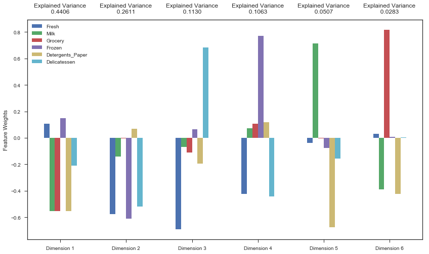

```python
# TODO: Apply PCA by fitting the good data with the same number of dimensions as features
from sklearn.decomposition import PCA
pca = PCA(n_components=len(good_data.keys()))
pca.fit(good_data)

# TODO: Transform log_samples using the PCA fit above
pca_samples = pca.transform(log_samples)

# Generate PCA results plot
pca_results = vs.pca_results(good_data, pca)
print pca_results['Explained Variance'].cumsum()
```

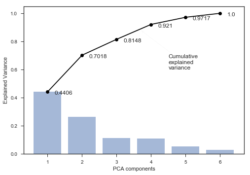

```python
# create an x-axis variable for each pca component
x = np.arange(1,7)

# plot the cumulative variance
plt.plot(x, np.cumsum(pca.explained_variance_ratio_), '-o', color='black')

# plot the components' variance
plt.bar(x, pca.explained_variance_ratio_, align='center', alpha=0.5)

# plot styling
plt.ylim(0, 1.05)
plt.annotate('Cumulative\nexplained\nvariance',
             xy=(3.7, .88), arrowprops=dict(arrowstyle='->'), xytext=(4.5, .6))
for i,j in zip(x, np.cumsum(pca.explained_variance_ratio_)):
    plt.annotate(str(j.round(4)),xy=(i+.2,j-.02))
plt.xticks(range(1,7))
plt.xlabel('PCA components')
plt.ylabel('Explained Variance')
plt.show()
```

### Question 5

- How much variance in the data is explained **in total** by the first and second principal component?
- How much variance in the data is explained by the first four principal components?
- Using the visualization provided above, talk about each dimension and the cumulative variance explained by each, stressing upon which features are well represented by each dimension(both in terms of positive and negative variance explained). Discuss what the first four dimensions best represent in terms of customer spending.

**Hint:** A positive increase in a specific dimension corresponds with an *increase* of the *positive-weighted* features and a *decrease* of the *negative-weighted* features. The rate of increase or decrease is based on the individual feature weights.

**Answer:**

### Observation

Run the code below to see how the log-transformed sample data has changed after having a PCA transformation applied to it in six dimensions. Observe the numerical value for the first four dimensions of the sample points. Consider if this is consistent with your initial interpretation of the sample points.

```python
# Display sample log-data after having a PCA transformation applied
display(pd.DataFrame(np.round(pca_samples, 4), columns = pca_results.index.values))
```

|  | Dimension 1 | Dimension 2 | Dimension 3 | Dimension 4 | Dimension 5 | Dimension 6 |
| --- | --- | --- | --- | --- | --- | --- |
| 0 | -1.1675 | -1.1825 | -0.0055 | -0.3582 | -0.2486 | 0.0841 |
| 1 | -0.9237 | 0.2779 | -0.7928 | 0.9962 | 0.0966 | -0.2049 |
| 2 | 0.8795 | -0.9020 | 0.1764 | -0.1564 | -0.2263 | -0.4680 |

### Implementation: Dimensionality Reduction

When using principal component analysis, one of the main goals is to reduce the dimensionality of the data — in effect, reducing the complexity of the problem. Dimensionality reduction comes at a cost: Fewer dimensions used implies less of the total variance in the data is being explained. Because of this, the *cumulative explained variance ratio* is extremely important for knowing how many dimensions are necessary for the problem. Additionally, if a signifiant amount of variance is explained by only two or three dimensions, the reduced data can be visualized afterwards.

In the code block below, you will need to implement the following:

- Assign the results of fitting PCA in two dimensions with `good_data` to `pca`.
- Apply a PCA transformation of `good_data` using `pca.transform`, and assign the results to `reduced_data`.
- Apply a PCA transformation of `log_samples` using `pca.transform`, and assign the results to `pca_samples`.

```python
# TODO: Apply PCA by fitting the good data with only two dimensions

pca = PCA(n_components=2)
pca.fit(good_data)

# TODO: Transform the good data using the PCA fit above
reduced_data = pca.transform(good_data)

# TODO: Transform log_samples using the PCA fit above
pca_samples = pca.transform(log_samples)

# Create a DataFrame for the reduced data
reduced_data = pd.DataFrame(reduced_data, columns = ['Dimension 1', 'Dimension 2'])
```

### Observation

Run the code below to see how the log-transformed sample data has changed after having a PCA transformation applied to it using only two dimensions. Observe how the values for the first two dimensions remains unchanged when compared to a PCA transformation in six dimensions.

```python
# Display sample log-data after applying PCA transformation in two dimensions
display(pd.DataFrame(np.round(pca_samples, 4), columns = ['Dimension 1', 'Dimension 2']))
```

|  | Dimension 1 | Dimension 2 |
| --- | --- | --- |
| 0 | -1.1675 | -1.1825 |
| 1 | -0.9237 | 0.2779 |
| 2 | 0.8795 | -0.9020 |

## Visualizing a Biplot

A biplot is a scatterplot where each data point is represented by its scores along the principal components. The axes are the principal components (in this case `Dimension 1` and `Dimension 2`). In addition, the biplot shows the projection of the original features along the components. A biplot can help us interpret the reduced dimensions of the data, and discover relationships between the principal components and original features.

Run the code cell below to produce a biplot of the reduced-dimension data.

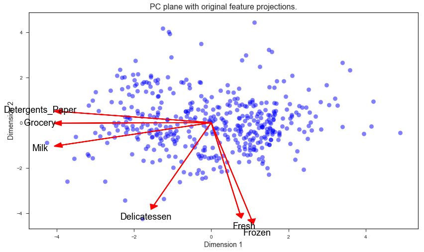

```python
# Create a biplot
vs.biplot(good_data, reduced_data, pca)
```

### Observation

From the biplot, which of the original features are most strongly correlated with the first component? What about those that are associated with the second component? Do these observations agree with the pca_results plot you obtained earlier?

## Clustering

In this section, you will choose to use either a K-Means clustering algorithm or a Gaussian Mixture Model clustering algorithm to identify the various customer segments hidden in the data. You will then recover specific data points from the clusters to understand their significance by transforming them back into their original dimension and scale.

### Question 6

- What are the advantages to using a K-Means clustering algorithm?
- What are the advantages to using a Gaussian Mixture Model clustering algorithm?
- Given your observations about the wholesale customer data so far, which of the two algorithms will you use and why?

**Hint:** Think about the differences between hard clustering and soft clustering and which would be appropriate for our dataset.

**Answer:**

- K-Means Clustering algorithm:  
  Advantages:

  ```
   1. easy to implement even on large data set; fast and efficient.
   2. hard clustering to generate distinct cluster.
  ```

- Gaussian Mixture Model Clustering algorithm:  
  Advantages:

  ```
   1. soft clustering is available, ie, data can belonged to multiply clusters
   2. Cluster can be in different shapes
   3. Good for data with Gaussian Distribution
  ```

- The K-Mean Clustering algorithm is more appreicated for our case is to identify the client type distinctly.

### Implementation: Creating Clusters

Depending on the problem, the number of clusters that you expect to be in the data may already be known. When the number of clusters is not known *a priori*, there is no guarantee that a given number of clusters best segments the data, since it is unclear what structure exists in the data — if any. However, we can quantify the "goodness" of a clustering by calculating each data point's *silhouette coefficient*. The [silhouette coefficient](http://scikit-learn.org/stable/modules/generated/sklearn.metrics.silhouette_score.html) for a data point measures how similar it is to its assigned cluster from -1 (dissimilar) to 1 (similar). Calculating the *mean* silhouette coefficient provides for a simple scoring method of a given clustering.

In the code block below, you will need to implement the following:

- Fit a clustering algorithm to the `reduced_data` and assign it to `clusterer`.
- Predict the cluster for each data point in `reduced_data` using `clusterer.predict` and assign them to `preds`.
- Find the cluster centers using the algorithm's respective attribute and assign them to `centers`.
- Predict the cluster for each sample data point in `pca_samples` and assign them `sample_preds`.
- Import `sklearn.metrics.silhouette_score` and calculate the silhouette score of `reduced_data` against `preds`.
  - Assign the silhouette score to `score` and print the result.

```python
# TODO: Apply your clustering algorithm of choice to the reduced data
from sklearn.cluster import KMeans
from sklearn.mixture import GaussianMixture
from sklearn.metrics import silhouette_score as silsc

def check_ClusterModel(clusterer, st, en, idata, sample, metricName):
    clusttype = type(clusterer).__name__
    ipreds = []
    icenters = []
    for i in range(st, en):
        if clusttype == "KMeans":
            clusterer = clusterer.set_params(n_clusters=i)
        else:
            clusterer = clusterer.set_params(n_components=i)
        clusterer.fit(idata)
        ipreds = clusterer.predict(idata)
        if clusttype == "KMeans":
            icenters = clusterer.cluster_centers_
        else:
            icenters = clusterer.means_
        pred_sample = clusterer.predict(sample)
        score = silsc(idata, ipreds, metric=metricName)
        print "silhouette score : {} with {} {} clusters".format(score, clusttype ,i)
#     print "{} - {}".format(type(icenters), type(ipreds))
    return icenters, ipreds, pred_sample

def check_GMMbyBIC(st, en, idata, sample, cv_types, useKMN):
    ipreds = []
    icenters = []
    lowest_bic = np.infty
    bic = []
    for i in range(st, en):
        if useKMN:
            KMN = KMeans(n_clusters=i)
            KMN.fit(idata)
        for cv in cv_types:
            if useKMN:
                clusterer = GaussianMixture(n_components=i, means_init=KMN.cluster_centers_,
                                            covariance_type=cv)
            else:
                clusterer = GaussianMixture(n_components=i, covariance_type=cv)
            clusterer.fit(idata)
            ipreds = clusterer.predict(idata)
            icenters = clusterer.means_
            pred_sample = clusterer.predict(sample)
            score = clusterer.bic(idata)
            print "BIC score : {:.1f} with GaussianMixture-{} {} clusters".format(score, cv ,i)
            bic.append(score)
            if bic[-1] < lowest_bic:
                lowest_bic = bic[-1]
                best_gmm = clusterer
                best_cv = cv
                best_num = i
    print "** The Best GaussianMixture BIC score is {:.1f} with covariance_type={}  {} clusters".format(lowest_bic, best_cv, best_num)
    return icenters, ipreds, pred_sample

cvtest = ['spherical', 'tied', 'diag', 'full']

print "** Test Loop for K-Means with 2-8 Clus=ters"
cc, pp, sm = check_ClusterModel(KMeans(), 2, 8, reduced_data, pca_samples, 'euclidean')
print "** Test Loop for Gaussian Mixture with 2-8 Clusters"
cc, pp, sm = check_ClusterModel(GaussianMixture(), 2, 8, reduced_data, pca_samples, 'mahalanobis')
print "** Test Loop for Gaussian Mixture with 2-8 Clusters using BIC score"
cc, pp, sm = check_GMMbyBIC(2, 8, reduced_data, pca_samples, cvtest, False)
print "** Test Loop for GMM init by KMN with 2-8 Clusters using BIC score"
cc, pp, sm = check_GMMbyBIC(2, 8, reduced_data, pca_samples, cvtest, True)
```

```
** Test Loop for K-Means with 2-8 Clus=ters
silhouette score : 0.415306893914 with KMeans 2 clusters
silhouette score : 0.394505961371 with KMeans 3 clusters
silhouette score : 0.336781566094 with KMeans 4 clusters
silhouette score : 0.353461933268 with KMeans 5 clusters
silhouette score : 0.361482355616 with KMeans 6 clusters
silhouette score : 0.36930442801 with KMeans 7 clusters
** Test Loop for Gaussian Mixture with 2-8 Clusters
silhouette score : 0.372294735496 with GaussianMixture 2 clusters
silhouette score : 0.296355736729 with GaussianMixture 3 clusters
silhouette score : 0.260684640448 with GaussianMixture 4 clusters
silhouette score : 0.322181056678 with GaussianMixture 5 clusters
silhouette score : 0.294076116787 with GaussianMixture 6 clusters
silhouette score : 0.285368136711 with GaussianMixture 7 clusters
** Test Loop for Gaussian Mixture with 2-8 Clusters using BIC score
BIC score : 3050.5 with GaussianMixture-spherical 2 clusters
BIC score : 3043.8 with GaussianMixture-tied 2 clusters
BIC score : 3050.1 with GaussianMixture-diag 2 clusters
BIC score : 3042.2 with GaussianMixture-full 2 clusters
BIC score : 3041.5 with GaussianMixture-spherical 3 clusters
BIC score : 3057.7 with GaussianMixture-tied 3 clusters
BIC score : 3068.8 with GaussianMixture-diag 3 clusters
BIC score : 3077.5 with GaussianMixture-full 3 clusters
BIC score : 3056.6 with GaussianMixture-spherical 4 clusters
BIC score : 3063.7 with GaussianMixture-tied 4 clusters
BIC score : 3069.3 with GaussianMixture-diag 4 clusters
BIC score : 3092.8 with GaussianMixture-full 4 clusters
BIC score : 3074.0 with GaussianMixture-spherical 5 clusters
BIC score : 3075.5 with GaussianMixture-tied 5 clusters
BIC score : 3097.0 with GaussianMixture-diag 5 clusters
BIC score : 3108.3 with GaussianMixture-full 5 clusters
BIC score : 3099.0 with GaussianMixture-spherical 6 clusters
BIC score : 3081.1 with GaussianMixture-tied 6 clusters
BIC score : 3119.5 with GaussianMixture-diag 6 clusters
BIC score : 3137.5 with GaussianMixture-full 6 clusters
BIC score : 3097.1 with GaussianMixture-spherical 7 clusters
BIC score : 3103.3 with GaussianMixture-tied 7 clusters
BIC score : 3148.5 with GaussianMixture-diag 7 clusters
BIC score : 3154.0 with GaussianMixture-full 7 clusters
** The Best GaussianMixture BIC score is 3041.5 with covariance_type=spherical  3 clusters
```

[output cut: 11 more lines]

```
BIC score : 3091.1 with GaussianMixture-diag 4 clusters
BIC score : 3092.8 with GaussianMixture-full 4 clusters
BIC score : 3056.1 with GaussianMixture-spherical 5 clusters
BIC score : 3076.2 with GaussianMixture-tied 5 clusters
BIC score : 3099.0 with GaussianMixture-diag 5 clusters
BIC score : 3106.8 with GaussianMixture-full 5 clusters
BIC score : 3100.4 with GaussianMixture-spherical 6 clusters
BIC score : 3081.5 with GaussianMixture-tied 6 clusters
BIC score : 3117.3 with GaussianMixture-diag 6 clusters
BIC score : 3147.1 with GaussianMixture-full 6 clusters
BIC score : 3088.8 with GaussianMixture-spherical 7 clusters
BIC score : 3093.6 with GaussianMixture-tied 7 clusters
BIC score : 3122.1 with GaussianMixture-diag 7 clusters
BIC score : 3153.7 with GaussianMixture-full 7 clusters
** The Best GaussianMixture BIC score is 3042.2 with covariance_type=full  2 clusters
```

```python
print "**  Final selection with best score **"
cvchoice = ['tied']
centers, preds, sample_preds = check_ClusterModel(KMeans(), 2, 3, reduced_data, pca_samples, 'euclidean')
# centers, preds, sample_preds = check_GMMbyBIC(2, 3, reduced_data, pca_samples, cvchoice, True)
```

```
**  Final selection with best score **
silhouette score : 0.415306893914 with KMeans 2 clusters
```

### Question 7

- Report the silhouette score for several cluster numbers you tried.
- Of these, which number of clusters has the best silhouette score?

**Answer:**

The detail out of K-Means and Gaussian Mixture using 2-8 clusters has displayed the result in the above section. There are try out run of Gaussian Mixture that using BIC score to find out best model with 3 clusters. But the third clusters of customers cannot be presented reasonable explainations of features. Therefore the best choice is :  
The best silhouette score would be obtanined by **K-Means** with **2 clusters**.

### Cluster Visualization

Once you've chosen the optimal number of clusters for your clustering algorithm using the scoring metric above, you can now visualize the results by executing the code block below. Note that, for experimentation purposes, you are welcome to adjust the number of clusters for your clustering algorithm to see various visualizations. The final visualization provided should, however, correspond with the optimal number of clusters.

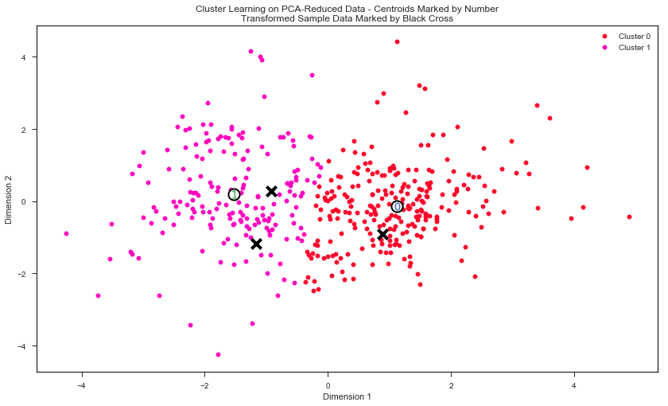

```python
# Display the results of the clustering from implementation
vs.cluster_results(reduced_data, preds, centers, pca_samples)
```

### Implementation: Data Recovery

Each cluster present in the visualization above has a central point. These centers (or means) are not specifically data points from the data, but rather the *averages* of all the data points predicted in the respective clusters. For the problem of creating customer segments, a cluster's center point corresponds to *the average customer of that segment*. Since the data is currently reduced in dimension and scaled by a logarithm, we can recover the representative customer spending from these data points by applying the inverse transformations.

In the code block below, you will need to implement the following:

- Apply the inverse transform to `centers` using `pca.inverse_transform` and assign the new centers to `log_centers`.
- Apply the inverse function of `np.log` to `log_centers` using `np.exp` and assign the true centers to `true_centers`.

```python
# TODO: Inverse transform the centers
log_centers = pca.inverse_transform(centers)
display(log_centers)

# Inverse transform Scaler
log_centers = scaler.inverse_transform(log_centers)
display(log_centers)

# TODO: Exponentiate the centers
true_centers = np.exp(log_centers)
display(true_centers)

# Display the true centers
segments = ['Segment {}'.format(i) for i in range(0,len(centers))]
true_centers = pd.DataFrame(np.round(true_centers), columns = data.keys())
true_centers.index = segments
display(true_centers)

cendiff = pd.DataFrame(columns = data.keys())
cendiff.at['mean'] = data.mean()
for i in range(0,len(true_centers)):
    na = 'Different-'+str(i)
    cendiff.at[na] = (true_centers.iloc[i]- data.mean())/data.mean()
display(cendiff)
```

```
array([[ 0.22430415, -0.59548807, -0.60643443,  0.27099878, -0.62540274,
        -0.14314733],
       [-0.24825674,  0.8282859 ,  0.86644099, -0.32702171,  0.8699282 ,
         0.24697162]])
```

```
array([[ 9.06230408,  7.47884196,  7.7689053 ,  7.65012269,  5.72385869,
         6.48607813],
       [ 8.36813747,  9.01567225,  9.40417948,  6.88439899,  8.27724953,
         6.9903025 ]])
```

```
array([[  8623.9981376 ,   1770.18964548,   2365.8799356 ,   2100.90333776,
           306.08372797,    655.94577753],
       [  4307.60552426,   8231.07787635,  12139.00958931,    976.91436094,
          3933.36088074,   1086.04995217]])
```

|  | Fresh | Milk | Grocery | Frozen | Detergents_Paper | Delicatessen |
| --- | --- | --- | --- | --- | --- | --- |
| Segment 0 | 8624.0 | 1770.0 | 2366.0 | 2101.0 | 306.0 | 656.0 |
| Segment 1 | 4308.0 | 8231.0 | 12139.0 | 977.0 | 3933.0 | 1086.0 |

|  | Fresh | Milk | Grocery | Frozen | Detergents_Paper | Delicatessen |
| --- | --- | --- | --- | --- | --- | --- |
| mean | 12000.3 | 5796.27 | 7951.28 | 3071.93 | 2881.49 | 1524.87 |
| Different-0 | -0.281351 | -0.694631 | -0.702438 | -0.316066 | -0.893805 | -0.5698 |
| Different-1 | -0.641009 | 0.420052 | 0.526673 | -0.681959 | 0.364917 | -0.287808 |

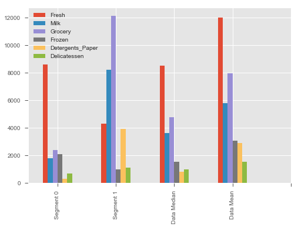

```python
trcenters = true_centers.copy()
trcenters.loc[trcenters.shape[0]] = data.median()
trcenters.loc[trcenters.shape[0]] = data.mean()

plt.style.use('ggplot')
trcenters.plot(kind='bar')
labels = true_centers.index.values.tolist()
labels.append("Data Median")
labels.append("Data Mean")
plt.xticks(range(trcenters.shape[0]+1),labels);
```

```python
display(trcenters)
```

|  | Fresh | Milk | Grocery | Frozen | Detergents_Paper | Delicatessen |
| --- | --- | --- | --- | --- | --- | --- |
| Segment 0 | 8624.000000 | 1770.000000 | 2366.000000 | 2101.000000 | 306.000000 | 656.000000 |
| Segment 1 | 4308.000000 | 8231.000000 | 12139.000000 | 977.000000 | 3933.000000 | 1086.000000 |
| 2 | 8504.000000 | 3627.000000 | 4755.500000 | 1526.000000 | 816.500000 | 965.500000 |
| 3 | 12000.297727 | 5796.265909 | 7951.277273 | 3071.931818 | 2881.493182 | 1524.870455 |

### Question 8

- Consider the total purchase cost of each product category for the representative data points above, and reference the statistical description of the dataset at the beginning of this project(specifically looking at the mean values for the various feature points). What set of establishments could each of the customer segments represent?

**Hint:** A customer who is assigned to `'Cluster X'` should best identify with the establishments represented by the feature set of `'Segment X'`. Think about what each segment represents in terms their values for the feature points chosen. Reference these values with the mean values to get some perspective into what kind of establishment they represent.

**Answer:**

The original dataset statistical description and the segment centers:

[output not shown]

### Question 9

- For each sample point, which customer segment from **Question 8** best represents it?
- Are the predictions for each sample point consistent with this?*

Run the code block below to find which cluster each sample point is predicted to be.

```python
# Display the predictions
for i, pred in enumerate(sample_preds):
    print "Sample point", i, "predicted to be in Cluster", pred
```

```
Sample point 0 predicted to be in Cluster 1
Sample point 1 predicted to be in Cluster 1
Sample point 2 predicted to be in Cluster 0
```

**Answer:**

[output not shown]

## Conclusion

In this final section, you will investigate ways that you can make use of the clustered data. First, you will consider how the different groups of customers, the *customer segments*, may be affected differently by a specific delivery scheme. Next, you will consider how giving a label to each customer (which *segment* that customer belongs to) can provide for additional features about the customer data. Finally, you will compare the *customer segments* to a hidden variable present in the data, to see whether the clustering identified certain relationships.

### Question 10

Companies will often run [A/B tests](https://en.wikipedia.org/wiki/A/B_testing) when making small changes to their products or services to determine whether making that change will affect its customers positively or negatively. The wholesale distributor is considering changing its delivery service from currently 5 days a week to 3 days a week. However, the distributor will only make this change in delivery service for customers that react positively.

- How can the wholesale distributor use the customer segments to determine which customers, if any, would react positively to the change in delivery service?*

**Hint:** Can we assume the change affects all customers equally? How can we determine which group of customers it affects the most?

**Answer:**

|  | **Segment 0** | **Segment 1** |
| --- | --- | --- |
| 5 days plan | 22 clients | 22 clients |
| 3 days plan | 22 clients | 22 clients |

The test may runs thought a week or more until the wholesale distributor receives enough feedbacks from clients to make a final decision. The wholesale distributor should make only apply the change to 3 days plan the segment of clients if the 3 days plan clients give the same or better rate of positive feedback compare to the positive feedback rate of 5 days plan.

By reviewing the important features of each segments, this is a possible outcome of the **A/B test**:  
**Segment 0** customers will mostly to purchase 'Frozen' and 'Fresh'. **segment 1** customers are likely to buy 'Detergents_Paper', 'Grocery', and 'Milk'. The change of delivery service from 5 days a week to 3 days a week will impact the customers who buy 'Milk' and 'Fresh' which is delivered daily providing a better quality. Customers buy others such as 'Detergents_Paper' or 'Grocery' should reacts positive to the service change.  
May be there should be a **Segment 2** to handle those customers who buy 'Milk' or 'Fresh'.

### Question 11

Additional structure is derived from originally unlabeled data when using clustering techniques. Since each customer has a *customer segment* it best identifies with (depending on the clustering algorithm applied), we can consider *'customer segment'* as an **engineered feature** for the data. Assume the wholesale distributor recently acquired ten new customers and each provided estimates for anticipated annual spending of each product category. Knowing these estimates, the wholesale distributor wants to classify each new customer to a *customer segment* to determine the most appropriate delivery service.

- How can the wholesale distributor label the new customers using only their estimated product spending and the **customer segment** data?

**Hint:** A supervised learner could be used to train on the original customers. What would be the target variable?

```python
from sklearn.neighbors import KNeighborsClassifier

train_data = data.drop(data.index[outliers]).reset_index(drop = True)
clf = KNeighborsClassifier()
clf.fit(train_data, preds)

##### new clients with projected spending
nclient = pd.DataFrame(columns = train_data.columns.values)

nclient.at[0] = [38009, 2000, 15000, 23490, 409, 1303]
nclient.at[1] = [3909, 1040, 18500, 100, 39091, 8809]
nclient.at[2] = [10000, 3430, 1200, 75000, 10000, 21000]

nclienttype = clf.predict(nclient)

for i in range(len(nclienttype)):
    print "New Client {} is predicted to be in Segment {}".format(i, nclienttype[i])
```

```
New Client 0 is predicted to be in Segment 0
New Client 1 is predicted to be in Segment 1
New Client 2 is predicted to be in Segment 0
```

**Answer:**

The wholesale distributor can use the customer segment as the label which either **segment 0** or **segment 1**. We can use the **K-Nearest Neighbor Classifier** with the original data to train the classifier to predict whether the new client is which segment. The above code is implemented the logic.

### Visualizing Underlying Distributions

At the beginning of this project, it was discussed that the `'Channel'` and `'Region'` features would be excluded from the dataset so that the customer product categories were emphasized in the analysis. By reintroducing the `'Channel'` feature to the dataset, an interesting structure emerges when considering the same PCA dimensionality reduction applied earlier to the original dataset.

Run the code block below to see how each data point is labeled either `'HoReCa'` (Hotel/Restaurant/Cafe) or `'Retail'` the reduced space. In addition, you will find the sample points are circled in the plot, which will identify their labeling.

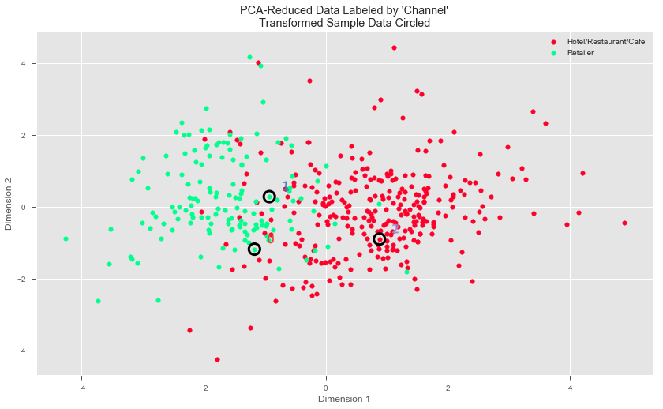

```python
# Display the clustering results based on 'Channel' data
vs.channel_results(reduced_data, outliers, pca_samples)
```

### Question 12

- How well does the clustering algorithm and number of clusters you've chosen compare to this underlying distribution of Hotel/Restaurant/Cafe customers to Retailer customers?
- Are there customer segments that would be classified as purely 'Retailers' or 'Hotels/Restaurants/Cafes' by this distribution?
- Would you consider these classifications as consistent with your previous definition of the customer segments?

**Answer:**

When comparing the clustered result, the segments is not fully predicting the channels Hotel/Resturant/Cafe customers to Retailer customers. The channels clusters are overlapped in the center, however there still pure 'Retailers' in far left and 'Hotels/Restaurants/Cafes' in far right. In general the overall classifications still consistent with my previous definition of customer segments.

> **Note**: Once you have completed all of the code implementations and successfully answered each question above, you may finalize your work by exporting the iPython Notebook as an HTML document. You can do this by using the menu above and navigating to  
> **File -> Download as -> HTML (.html)**. Include the finished document along with this notebook as your submission.